# Rによる機械学習 ランダムフォレスト

Cho（ztempest0218@gmail.com）

Last Updated: 2026-11-20

**データのダウンロード**

- 演習データ：train.csv を `data/titanic/` に保存する。

**今回の内容**

- ランダムフォレストの仕組み
- OOBによるハイパーパラメーターのチューニング
- 交差検証による複数ハイパーパラメーターのチューニング

# 1 一枚の葉から考える

前回の決定木では、乗客を質問で分け、**同じ葉に入った学習データ**の多数決で生存・死亡を予測した。この点でk-NNと似ているが、k-NNは距離が近い $k$ 人を使うのに対し、決定木では分岐の結果、葉に入る人数が葉ごとに変わる。

次の7人が同じ葉に入ったと考え、この葉に来た乗客の生存・死亡を予測してみよう。

表1

| 番号 | 年齢 | 客室等級 | 性別 | 結果 |
| --- | --- | --- | --- | --- |
| A | 8 | 3等 | 女性 | 生存 |
| B | 12 | 2等 | 男性 | 生存 |
| C | 20 | 3等 | 男性 | 死亡 |
| D | 30 | 2等 | 女性 | 生存 |
| E | 42 | 3等 | 男性 | 死亡 |
| F | 50 | 1等 | 男性 | 死亡 |
| G | 55 | 3等 | 男性 | 死亡 |

この葉には、生存したA・B・Dの3人と死亡したC・E・F・Gの4人がいる。多数決では「死亡」と予測する。Cが含まれなければ、生存・死亡が3人ずつで同数になる。このように、決定木は学習データが少し変わるだけで、葉の構成や予測が変わる。

# 2 ランダムフォレスト

一本の決定木は、学習データのわずかな違いによって予測が変わりやすい。そこで、**ランダムフォレスト（Random Forest）**では、少しずつ異なる**複数の決定木を作り**、それぞれの予測を組み合わせる。分類では、一本の木の予測を一票として、すべての木の多数決で最終的な予測を決める。同じ学習データと特徴量を使い、ジニ不純度に基づく同じ手順で木を作ると、同じ木ができる。そこで、ランダムフォレストでは、どのように異なる木を作るかが重要になる。

## 2.1 復元抽出・ブートストラップ標本とバギング

**復元抽出**とは、データから観測を一つ無作為に選び、**元に戻してから**次の観測を選ぶ方法である。抽出のたびに同じデータ全体から選ぶため、同じ観測が複数回選ばれることも、一度も選ばれない観測があることもある。元のデータから復元抽出して得られた標本を**ブートストラップ標本（bootstrap sample）**という。通常は元のデータと同じ数だけ抽出する。

表1のサンプルから7回抽出し、ブートストラップ標本を作ってみよう。ここでは3つの標本を作り、それぞれを使って木を1本ずつ育てる。下の図で木1〜木3の標本を確かめよう（抽出例はあらかじめ固定している）。

抽出例

**袋の中**7枚

ABCDEFG

1枚引く**⟶****⟵**袋に戻す

引いたカード**B**

**引いた順に記録**3 / 7 回

1. 1回目**A**
2. 2回目**B**
3. 3回目**B**
4. 4回目**–**
5. 5回目**–**
6. 6回目**–**
7. 7回目**–**

木を1本育てるたびに、元の7人から新しいブートストラップ標本を作る。下の表で、各木の標本に誰が何回入ったかを比べてみよう。

| 育てる木 | 7回引いた結果 | 一度でも入った人数 | 一度も入らなかった人 |
| --- | --- | --- | --- |
| **木1** | A・B・B・C・E・F・A | 5人 | D・G |
| **木2** | B・C・D・D・F・F・D | 4人 | A・E・G |
| **木3** | A・A・C・D・F・F・A | 4人 | B・E・G |

このように、木は1本につき一つのブートストラップ標本を使い、各木は**異なるブートストラップ標本**から学習する。復元抽出では、外れ値を含め、各観測が選ばれる確率は等しい。一部の木には特定の観測が含まれないため、複数の木の予測をまとめることで、一つの観測が全体の予測に与える影響を小さくできる。

複数のモデルの予測を組み合わせる方法を**アンサンブル学習（ensemble learning）**という。その一つである**バギング（bagging, bootstrap aggregating）**では、元のデータからブートストラップ標本をそれぞれ独立に作り、同じ種類のモデルを別々に学習して予測をまとめる。各モデルはほかのモデルの結果を待たずに学習でき、**並行（parallel）**して作ることもできる。分類では多数決、回帰では平均で予測をまとめる。ここでは決定木を使い、異なる標本から木を作る。

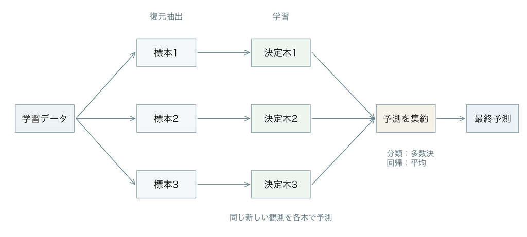

## 2.2 特徴量 $X$ の無作為抽出

バギングでは、異なるブートストラップ標本から木を作る。それでも、予測に強く関係する特徴量があれば、多くの木が同じ特徴量で分岐し、構造や予測が似やすい。例えば、タイタニック号のデータでは女性の生存率が約74%、男性が約19%である。生存率の差が大きいため、性別は多くの木で最初の質問に選ばれやすい。

そこでランダムフォレストでは、**分岐ごとに特徴量の候補を無作為に選ぶ**。性別がたまたま候補に入らなかった分岐では、年齢や客室等級などから質問を選ぶ。通常の決定木は、各分岐でその時点の不純度を最も減らす質問を選ぶ**貪欲法（greedy algorithm）**である。ランダムフォレストでも、選ばれた候補の中で同じ基準を使う。

今回の実習では7つの特徴量を使う。各分岐で、質問を選ぶ前に無作為に取り出す特徴量の数を `mtry` とする。例えば `mtry = 4` なら、7つの特徴量から4つを無作為に選び、その中から最もよい質問を決める。次の分岐では、また4つを選び直す。`mtry = 7` なら毎回すべての特徴量が候補になる。各分岐では、選ばれた特徴量の中から最もよく分けられる質問を選ぶため、候補に入った特徴量によって木の分かれ方が変わる。

候補の数（mtry）

性別客室等級年齢運賃兄弟姉妹・配偶者親・子乗船港

多くの木が同じ乗客について予測を外すと、多数決でもその誤りを補いにくい。`mtry` を小さくすると木ごとに異なる質問を選びやすくなるが、有力な特徴量が候補に入らず、個々の木の予測精度が下がることもある。そこで、実習では異なる `mtry` を試し、OOB誤り率を比べて最もよい設定を選ぶ。

ランダムフォレストでは、前回の**決定木のように剪定せず**、各木を深く育ててデータの細かな特徴を学習する。個々の木に偶然による誤りがあっても、すべての木の予測をまとめることで、その影響を小さくできる。

## 2.3 Out-of-bag

**元のデータ**

復元抽出

**ブートストラップ標本**抽出された観測：木の学習に使う

**OOB（out-of-bag）データ**一度も抽出されなかった観測

ブートストラップ標本には、一度も抽出されない観測がある。このような観測を、その木の **OOB（out-of-bag）**という。OOBの観測はその木の学習に使われていないため、未知のデータのように扱い、予測と実際の結果を比べられる。

$n$ 人から復元抽出を $n$ 回行うと、ある乗客が一度も選ばれない確率は $(1-1/n)^n$ で、$n$ が大きいと約36.8%になるため、501本の森ではその乗客のOOB予測に平均約184本の木が投票する。

2.1節の木1〜木3に、木4と木5を加えてみよう。乗客Aは木1と木3の標本には含まれ、木2・木4・木5の標本には含まれていない。そこで、**木2・木4・木5の予測をまとめて**、AのOOB予測を作る。

| 木 | Aが抽出されたか | Aの予測 | AのOOB予測に使うか |
| --- | --- | --- | --- |
| 木1 | Yes | 生存 | No |
| 木2 | No | 生存 | Yes |
| 木3 | Yes | 生存 | No |
| 木4 | No | 死亡 | Yes |
| 木5 | No | 生存 | Yes |

木2・木4・木5の予測は生存2票、死亡1票なので、AのOOB予測は「生存」である。表1でAは実際に生存しているので、この予測は正しい。同様に各観測のOOB予測を実際の結果と比べ、例えば100人のうち20人で外れたなら、OOB誤り率は20%となる。 **OOB誤り率（out-of-bag error rate）**はモデルの予測性能を評価する一つの指標である。OOB正解率は $1 - \text{OOB誤り率}$ から計算できる。

OOBとk分割交差検証は、どちらも予測性能の評価や設定の比較に使える。

|  | OOB | k分割交差検証 |
| --- | --- | --- |
| 評価 | 各木の未使用データ | 順番に分けた検証データ |
| 前処理 | OOBデータが補完値に影響する場合がある | 分割ごとに学習部分だけで行える |
| 計算量 | 少ない | 多い |

## 2.4 パラメーターとハイパーパラメーター

ランダムフォレストでは、各木の分岐ルールや葉の予測値が学習データから決まる。ここでは、これらを学習するパラメーターとして考える。一方、木の本数や分岐の候補数など、学習前に設定する条件が**ハイパーパラメーター**である。

| 種類 | 内容 | この実習での扱い |
| --- | --- | --- |
| パラメーター | 各木の分岐に使う特徴量と分け方 | 学習データから決める |
| パラメーター | 各木の葉の予測値 | 学習データから求める |
| ハイパーパラメーター | `ntree`：木の本数 | 501本に固定 |
| ハイパーパラメーター | `mtry`：各分岐で候補にする特徴量の数 | OOB誤り率で比較する |
| ハイパーパラメーター | `nodesize`：葉に含まれる観測数の下限 | 交差検証で比較する |

分類では、特徴量の総数を $p$ とすると、$\sqrt{p}$ が `mtry` の経験則として使われる。`randomForest` パッケージではその切り捨て値がデフォルトだが、最良とは限らない。候補を交差検証やOOB誤り率で比較して選ぶことができる。

今回使う `randomForest` には、前回の `rpart` で剪定に使った `cp` はない。木の複雑さは、例えば葉の観測数の下限を決める `nodesize` や、葉の数の上限を決める `maxnodes` で調整できる。基本の分析ではこれらを指定せず、デフォルト値を使う。3.6節では `nodesize` をハイパーパラメーターとして交差検証で比較する。

# 3 Rでタイタニック号の乗客の生存を予測する

前回と同じタイタニック号のデータと学習・検証データの分け方を使う。前回の3特徴量の決定木と、今回の7特徴量のランダムフォレストを比べ、どの特徴量が森林の生存予測に役立ったかを調べよう。

```r
# 初回のみ：install.packages(c("randomForest", "recipes", "gmodels", "tidyverse"))
library(randomForest)
library(tidyverse)
library(recipes)
library(rpart)
library(gmodels)
```

## 3.1 データの読み込みと前処理

前回使った性別（`sex`）・客室等級（`pclass`）・年齢（`age`）に、運賃（`fare`）、兄弟姉妹・配偶者の人数（`sibsp`）、親・子の人数（`parch`）、乗船港（`embarked`）を加える。

```r
# データを読み込み、使う列を選ぶ
passengers <- read.csv("data/titanic/train.csv", na.strings = c("", "NA"))
passengers <- passengers[c("Survived", "Sex", "Pclass", "Age",
                           "Fare", "SibSp", "Parch", "Embarked")]
head(passengers)
```

|  | Survived | Sex | Pclass | Age | Fare | SibSp | Parch | Embarked |
| --- | --- | --- | --- | --- | --- | --- | --- | --- |
| 1 | 0 | male | 3 | 22 | 7.2500 | 1 | 0 | S |
| 2 | 1 | female | 1 | 38 | 71.2833 | 1 | 0 | C |
| 3 | 1 | female | 3 | 26 | 7.9250 | 0 | 0 | S |
| 4 | 1 | female | 1 | 35 | 53.1000 | 1 | 0 | S |
| 5 | 0 | male | 3 | 35 | 8.0500 | 0 | 0 | S |
| 6 | 0 | male | 3 | NA | 8.4583 | 0 | 0 | Q |

実習に使う変数は次のとおりである。

| 変数名 | 内容 |
| --- | --- |
| `Survived` | 生存・死亡（0：死亡、1：生存） |
| `Sex` | 性別 |
| `Pclass` | 客室等級（1等・2等・3等） |
| `Age` | 年齢 |
| `Fare` | 運賃 |
| `SibSp` | 同乗した兄弟姉妹・配偶者の人数 |
| `Parch` | 同乗した親・子の人数 |
| `Embarked` | 乗船港（C・Q・S） |

```r
# 列名を小文字に統一する
names(passengers) <- tolower(names(passengers))

# 目的変数とカテゴリ変数を因子にする
passengers$survived <- factor(passengers$survived, levels = c(0, 1),
                              labels = c("Lost", "Survived"))
passengers$pclass <- factor(passengers$pclass, levels = 1:3)
passengers$sex <- factor(passengers$sex)
passengers$embarked <- factor(passengers$embarked, levels = c("C", "Q", "S"))

# 生存予測に使う特徴量（候補）を指定する
predictors <- c("sex", "pclass", "age", "fare", "sibsp", "parch", "embarked")
```

前回と同じ乱数の種で、約80%を学習用、残りを検証用に分ける。

```r
# 前回と同じデータ分割を使う
set.seed(2026)
train_id <- sample(seq_len(nrow(passengers)), size = floor(0.8 * nrow(passengers)))
ship_train <- passengers[train_id, ]
ship_validation <- passengers[-train_id, ]

table(ship_train$survived)
```

```
##
##     Lost Survived
##      433      279
```

学習データの死亡者は 433 人、生存者は 279 人で、前回と同じである。

今回使う `randomForest()` は、前回の `rpart` のような代理分岐に対応していないため、学習前に欠損値を処理する必要がある。欠損値の補完は手間がかかるが、データの構造を考える特徴量エンジニアリングの練習にもなる。

ここでは簡単のため、数値の欠損を学習データ全体の中央値、カテゴリの欠損を最頻値で補う。検証データにも学習データから求めた値を使う。

```r
# 数値は中央値、カテゴリは最頻値で補う
rec <- recipe(survived ~ ., data = ship_train) %>%
  step_impute_median(all_numeric_predictors()) %>%
  step_impute_mode(all_nominal_predictors()) %>%
  prep(training = ship_train)

# 学習データと検証データの欠損を補完する
ship_train_imputed <- bake(rec, new_data = ship_train)
ship_validation_imputed <- bake(rec, new_data = ship_validation)
```

## 3.2 ランダムフォレストの学習

7つの特徴量を使う。計算量を抑えるため、ここでは木の本数を501本に固定する。各木の学習前にブートストラップ標本を一つ作るため、木の本数は標本を作る回数にも当たる。まず分岐の候補数 `mtry` を1から7まで変え、OOB誤り率を比較する。

`for` ループを復習しよう。繰り返し変数にベクトルの値を一つずつ代入し、波括弧の中の処理を繰り返す。

```r
for (i in 1:5) {
  print(i)
}
```

```
## [1] 1
## [1] 2
## [1] 3
## [1] 4
## [1] 5
```

一般的な書き方は次の通りである。

```r
for (繰り返し変数 in 繰り返す値のベクトル) {
  # 繰り返したい処理
}
```

以下では、`m` に `mtry_values` の値を一つずつ代入して、候補ごとにモデルを学習する。

```r
# 目的変数と7つの特徴量を指定する
formula <- survived ~ sex + pclass + age + fare + sibsp + parch + embarked

# 比較する候補数を1から7まで用意する
mtry_values <- 1:7

# 各候補数のOOB誤り率を記録するベクトルを用意する
oob_error <- c(0, 0, 0, 0, 0, 0, 0)

# ループで候補数ごとに森を作り、OOB誤り率を記録する
set.seed(2026)
for (m in mtry_values) {
  model <- randomForest(formula, data = ship_train_imputed, ntree = 501, mtry = m)
  oob_error[m] <- model$err.rate[501, "OOB"]
}
data.frame(mtry = mtry_values, `OOB Error Rate` = oob_error)
```

| mtry | OOB.Error.Rate |
| --- | --- |
| 1 | 0.1713483 |
| 2 | 0.1741573 |
| 3 | 0.1699438 |
| 4 | 0.1685393 |
| 5 | 0.1713483 |
| 6 | 0.1783708 |
| 7 | 0.1783708 |

OOB誤り率が最も低い設定を選ぶ。同率の場合は小さい `mtry` を使う。

```r
# OOB誤り率が最小の候補数を選ぶ
best_mtry <- mtry_values[which.min(oob_error)]
best_mtry
```

```
## [1] 4
```

```r
# 選んだ候補数で森を学習し、変数重要度も計算する
set.seed(2026)
forest <- randomForest(formula, data = ship_train_imputed,
                       ntree = 501, mtry = best_mtry, importance = TRUE)

# 学習した森の概要を確認する
forest
```

```
##
## Call:
##  randomForest(formula = formula, data = ship_train_imputed, ntree = 501,      mtry = best_mtry, importance = TRUE)
##                Type of random forest: classification
##                      Number of trees: 501
## No. of variables tried at each split: 4
##
##         OOB estimate of  error rate: 16.99%
## Confusion matrix:
##          Lost Survived class.error
## Lost      381       52   0.1200924
## Survived   69      210   0.2473118
```

今回は `mtry =` 4 を選んだ。選んだ設定で改めて学習した森のOOB誤り率は 16.99% である。補完値は学習データ全体から求めているため、OOBの各観測の値も補完値に影響する場合がある。

### 3.2.1 木の本数とOOB誤り率

木の本数を増やすとOOB誤り率の揺れが小さくなりやすいが、計算量も増える。選んだ森林について、1本目から順に木を加えたときのOOB誤り率を確認しよう。

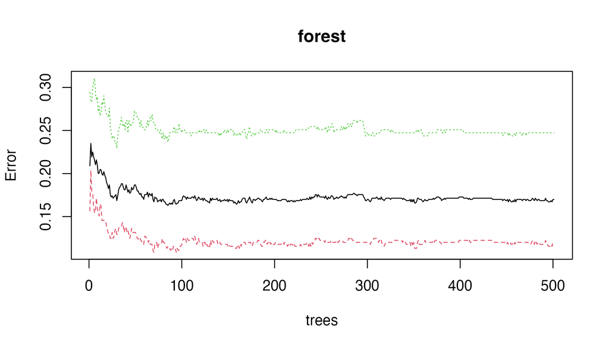

```r
# 全体とクラス別のOOB誤り率
plot(forest)
```

黒線は全体のOOB誤り率、赤線は死亡者、緑線は生存者のクラス別誤り率を表す。この例では木を増やすにつれて誤り率の変化が小さくなり、おおむね安定している。木の本数は、OOB誤り率の推移が十分に落ち着くかを見ながら、計算時間も考慮して選ぶ。501本が常に最適とは限らず、この図だけで厳密な収束は証明できない。

## 3.3 検証データでの予測

検証データを予測し、実際の結果と比べる。混同行列の行は実際、列は予測を表し、対角線上の行割合が再現率である。

```r
# 検証データを予測する
forest_pred <- predict(forest, ship_validation_imputed)
actual <- ship_validation$survived

# 混同行列
CrossTable(actual, forest_pred,
           dnn = c("Actual", "Predicted"),
           prop.r = TRUE, prop.c = FALSE, prop.t = FALSE, prop.chisq = FALSE)
```

```
##
##
##    Cell Contents
## |-------------------------|
## |                       N |
## |           N / Row Total |
## |-------------------------|
##
##
## Total Observations in Table:  179
##
##
##              | Predicted
##       Actual |      Lost |  Survived | Row Total |
## -------------|-----------|-----------|-----------|
##         Lost |       102 |        14 |       116 |
##              |     0.879 |     0.121 |     0.648 |
## -------------|-----------|-----------|-----------|
##     Survived |        22 |        41 |        63 |
##              |     0.349 |     0.651 |     0.352 |
## -------------|-----------|-----------|-----------|
## Column Total |       124 |        55 |       179 |
## -------------|-----------|-----------|-----------|
##
##
```

```r
# 全体の正解率を求める
mean(forest_pred == actual)
```

```
## [1] 0.7988827
```

## 3.4 決定木と比較する

前回の3特徴量の決定木と、3特徴量・7特徴量のランダムフォレストを、同じ検証データで比較する。3特徴量のランダムフォレストは学習過程を省略し、結果だけを示す。講義中のコードを変更して、各自で確認してみよう。

| モデル | 正解率 | 死亡者 再現率 | 生存者 再現率 | 死亡→生存 誤分類 | 生存→死亡 誤分類 |
| --- | --- | --- | --- | --- | --- |
| 前回の決定木（3特徴量） | 78.2% | 88.8% | 58.7% | 13 | 26 |
| ランダムフォレスト（3特徴量） | 78.8% | 87.9% | 61.9% | 14 | 24 |
| ランダムフォレスト（7特徴量） | 79.9% | 87.9% | 65.1% | 14 | 22 |

3特徴量の森林は性別・客室等級・年齢を使い、木は501本、`mtry = 1` とした。決定木と森林では特徴量や欠損値の扱いも異なる。

正解率の上昇は小さいが、生存者の再現率は決定木の 58.7%から7特徴量の森林では 65.1%に上がった。特徴量が少ないと、木の分岐に使える情報も限られる。 運賃や家族の人数などを加えると、異なる分岐を持つ木を作りやすくなり、予測の改善につながることがある。

## 3.5 変数重要度

どの特徴量が予測に役立ったかを調べよう。例えば、各木のOOBデータで、乗客の性別だけを無作為に入れ替え、同じ木でもう一度予測する。正解率が大きく下がれば、その木は性別を頼りにしていたと考えられる。この正解率の低下幅を各木について求め、平均したものを**置換重要度**という。

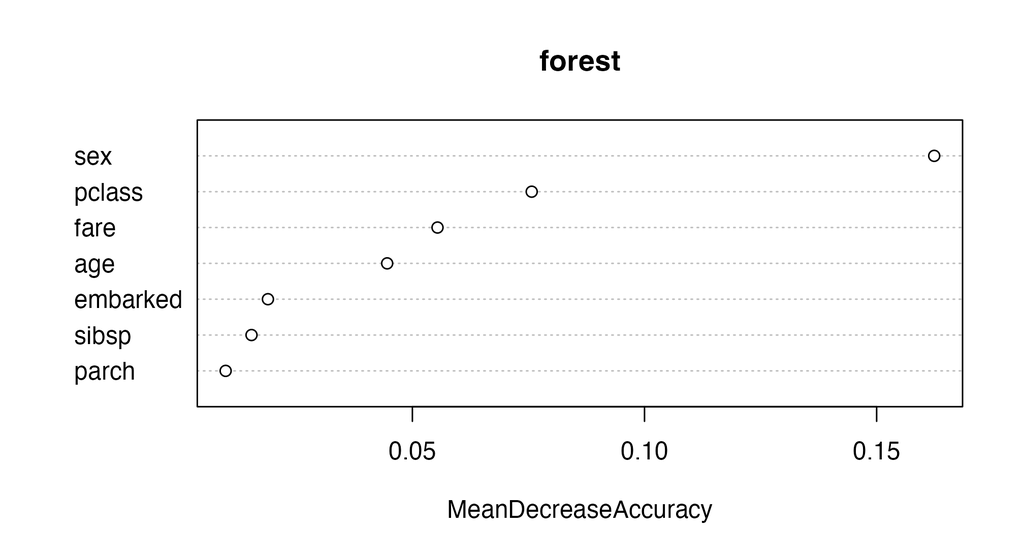

```r
# 置換重要度を表示する
varImpPlot(forest, type = 1, scale = FALSE)
```

今回の森林では、性別（`sex`）の置換重要度が最も高く、性別を並べ替えるとOOB正解率は平均 16.2 ポイント下がった。

## 3.6 交差検証でハイパーパラメーターを選ぶ

ここまでは木を501本に固定し、OOB誤り率で `mtry` を選んだ。今度は学習データを5分割し、交差検証の正解率で①木の本数、②`mtry`、③`nodesize` の3つのハイパーパラメーターの組み合わせを比べる。各分割では、学習部分から欠損値の補完ルールを求め、残りの部分に適用する。

```r
# 初回のみ：install.packages("caret")
library(caret)

# 各分割で学習する補完ルール
cv_recipe <- recipe(survived ~ ., data = ship_train) %>%
  step_impute_median(all_numeric_predictors()) %>%
  step_impute_mode(all_nominal_predictors())

# 比較するすべての設定で同じ5分割を使う
set.seed(2026)
cv_folds <- createFolds(ship_train$survived, k = 5, returnTrain = TRUE)
cv_control <- trainControl(method = "cv", number = 5, index = cv_folds)

# 比較するハイパーパラメーター
trees <- c(101, 301, 501)
nodes <- c(1, 5, 10)
mtry_values <- 1:7
```

3つのハイパーパラメーターの候補を増やすと、組み合わせごとに交差検証を行うため、計算時間が長くなる。授業では候補を少なくしているが、それぞれのベクトルを変更して、より多くの組み合わせを試すことができる。

`caret` でランダムフォレストを使うには `method = "rf"` を指定する。ここでは3つのループで木の本数、`nodesize`、`mtry` の候補を順に変え、すべての組み合わせを比較する。`tuneGrid` に複数の `mtry` を渡して自動で比較する方法もある。

```r
cv_results <- data.frame()

# 3つのハイパーパラメーターの組み合わせを順に試す
for (t in trees) {
  for (n in nodes) {
    for (m in mtry_values) {
      set.seed(2026)
      cv_model <- train(cv_recipe, data = ship_train,
                        method = "rf", trControl = cv_control,
                        tuneGrid = data.frame(mtry = m),
                        ntree = t, nodesize = n, metric = "Accuracy")
      cv_results <- rbind(cv_results,
                          data.frame(ntree = t, nodesize = n,
                                     cv_model$results[c("mtry", "Accuracy")]))
    }
  }
}

# 交差検証の平均正解率を比べる
cv_results
```

| ntree | nodesize | mtry | Accuracy |
| --- | --- | --- | --- |
| 101 | 1 | 1 | 0.8189008 |
| 101 | 1 | 2 | 0.8188614 |
| 101 | 1 | 3 | 0.8188713 |
| 101 | 1 | 4 | 0.8118389 |
| 101 | 1 | 5 | 0.8118290 |
| 101 | 1 | 6 | 0.8160642 |
| 101 | 1 | 7 | 0.8104206 |
| 101 | 5 | 1 | 0.8258741 |
| 101 | 5 | 2 | 0.8160248 |
| 101 | 5 | 3 | 0.8216586 |

[output cut: 53 more lines]

下の図は、すべての組み合わせの交差検証結果を可視化したものである。各マスが1つの設定を表す。色と数字は5分割交差検証の平均正解率を示す。

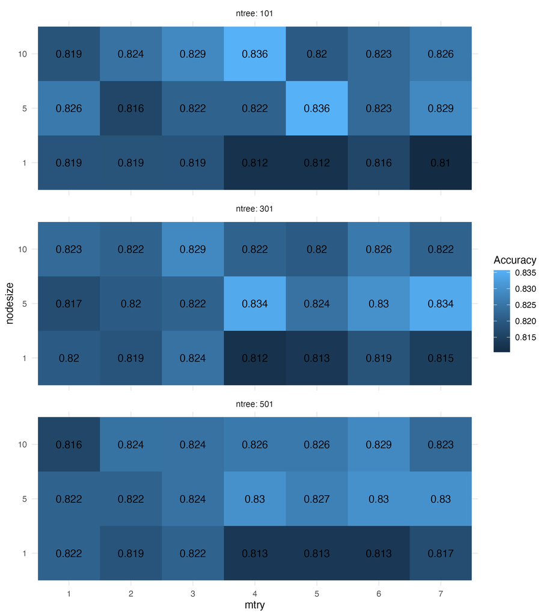

```r
# 組み合わせごとの平均正解率を表示する
ggplot(cv_results, aes(x = factor(mtry), y = factor(nodesize), fill = Accuracy)) +
  geom_tile() +
  geom_text(aes(label = round(Accuracy, 3))) +
  facet_wrap(~ ntree, ncol = 1, labeller = label_both) +
  labs(x = "mtry", y = "nodesize") +
  theme_minimal()
```

平均正解率が最も高い組み合わせを選ぶ。同じ場合は、木の本数が少なく、次に `nodesize` が大きい設定を優先する。それでも同じ場合は `mtry` が小さい設定を選ぶ。

```r
cv_results <- cv_results[order(-cv_results$Accuracy, cv_results$ntree,
                               -cv_results$nodesize, cv_results$mtry), ]
best_cv <- cv_results[1, ]
best_cv
```

|  | ntree | nodesize | mtry | Accuracy |
| --- | --- | --- | --- | --- |
| 18 | 101 | 10 | 4 | 0.8356939 |

選んだ設定は、木が 101 本、`mtry =` 4 、`nodesize =` 10 で、5分割の平均正解率は 83.6% だった。この値は試した候補から選んだ結果である。

この設定で学習データ全体を使って改めて学習し、検証データで予測する。

```r
# 選んだ設定で学習データ全体から森林を作る
set.seed(2026)
cv_forest <- randomForest(formula, data = ship_train_imputed,
                          ntree = best_cv$ntree, mtry = best_cv$mtry,
                          nodesize = best_cv$nodesize)

# 検証データの正解率と混同行列
cv_pred <- predict(cv_forest, ship_validation_imputed)
mean(cv_pred == ship_validation$survived)
```

```
## [1] 0.8044693
```

```r
CrossTable(ship_validation$survived, cv_pred,
           dnn = c("Actual", "Predicted"),
           prop.r = TRUE, prop.c = FALSE, prop.t = FALSE, prop.chisq = FALSE)
```

```
##
##
##    Cell Contents
## |-------------------------|
## |                       N |
## |           N / Row Total |
## |-------------------------|
##
##
## Total Observations in Table:  179
##
##
##              | Predicted
##       Actual |      Lost |  Survived | Row Total |
## -------------|-----------|-----------|-----------|
##         Lost |       105 |        11 |       116 |
##              |     0.905 |     0.095 |     0.648 |
## -------------|-----------|-----------|-----------|
##     Survived |        24 |        39 |        63 |
##              |     0.381 |     0.619 |     0.352 |
## -------------|-----------|-----------|-----------|
## Column Total |       129 |        50 |       179 |
## -------------|-----------|-----------|-----------|
##
##
```

3.4節の比較表に、交差検証で設定を選んだ森林を加える。

| モデル | 正解率 | 死亡者 再現率 | 生存者 再現率 | 死亡→生存 誤分類 | 生存→死亡 誤分類 |
| --- | --- | --- | --- | --- | --- |
| 前回の決定木（3特徴量） | 78.2% | 88.8% | 58.7% | 13 | 26 |
| ランダムフォレスト（3特徴量） | 78.8% | 87.9% | 61.9% | 14 | 24 |
| ランダムフォレスト（7特徴量） | 79.9% | 87.9% | 65.1% | 14 | 22 |
| 交差検証で選んだ森林（7特徴量） | 80.4% | 90.5% | 61.9% | 11 | 24 |

Kaggleのタイタニック号コンペでは全体の正解率で評価する。この検証データでは、交差検証で設定を選んだ森林の正解率が4つの中で最も高い。一方、生存者の再現率は死亡者より低く、生存者を正しく見つけることが難しい。生存者の再現率を重視すると、3つ目の7特徴量の森林が最も高い。評価指標によって、選ぶモデルは変わる。

# 4 まとめ

ランダムフォレストは、異なるブートストラップ標本から**複数の決定木**を作り、各分岐で使う**特徴量の候補も無作為に選ぶ**。分類では、各木の予測を多数決でまとめる。回帰では、各木の予測値の平均を使う。

木の本数 `ntree`、分岐の候補数 `mtry`、木の成長を調整する `nodesize` などのハイパーパラメーターは、予測性能や計算量に影響する。OOB誤り率や交差検証を使って、候補を比較できる。

Kaggleには正解率100%の投稿もあるが、公開された生存情報が使われている可能性もある。正解率80%を一つの目安に、名前や家族構成などから特徴量を工夫してみよう。